# Tidyverse tutorial Report

# Visualising

Before running models, it’s a good idea to visualise our data to explore what kind of distribution we are working with.

Let’s make a nice plot using the custom theme_LPD

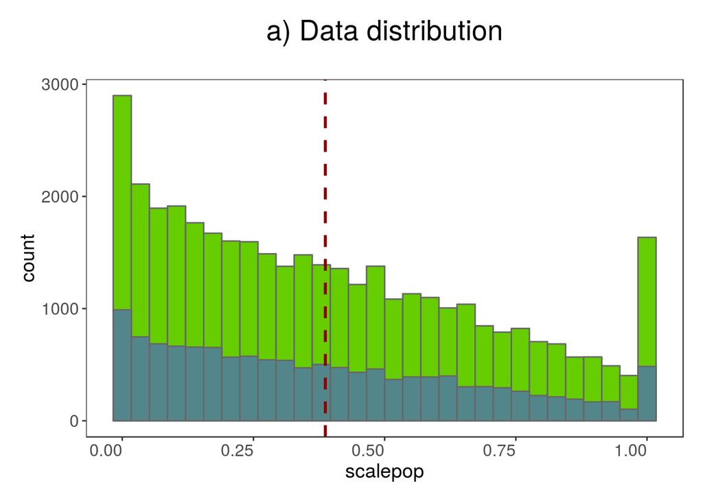

```r
(forest_histo <-
   ggplot(LPD_forest, aes(x = scalepop)) +
   geom_histogram(aes(fill = biome),
                  position = "identity", colour = "grey40") +
   geom_vline(aes(xintercept = mean(scalepop)),  # Adding a line for mean abundance
              colour = "darkred", linetype = "dashed", size = 1) +
   scale_fill_manual(values = c("#66CD00", "#53868B")) +
   theme_LPD() +
   labs(title = "a) Data distribution\n") +
   guides(fill = FALSE)) # Hiding the legend - this will be a two plot panel
```

```r
                        # thus we don't need the same legend twice
```

Next up we can explore for how long populations have been monitored in the two biomes using a density histogram.

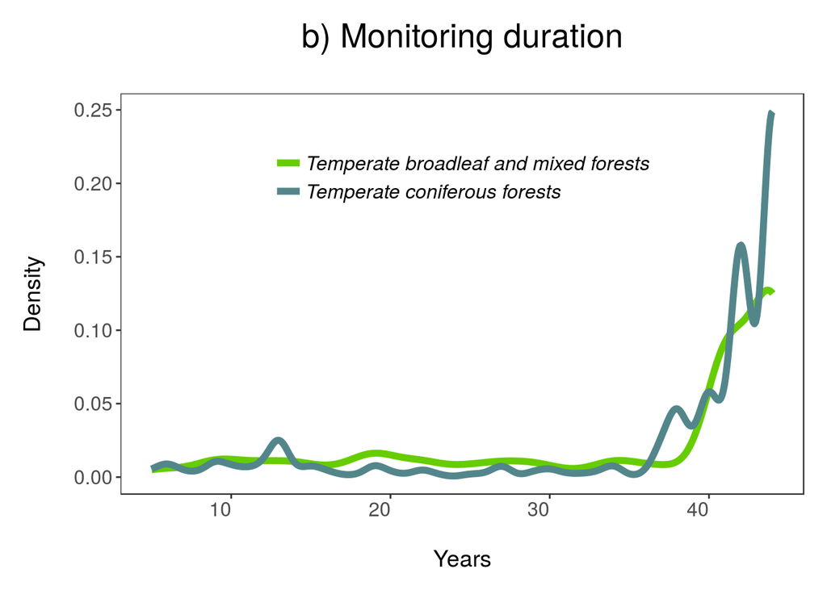

```r
(duration_forests <- ggplot(LPD_forest, aes(duration, colour = biome)) +
   # instead of using geom_density we will draw the upper line with
   # stat_density
    stat_density(geom = "line", size = 2, position = "identity") +
    theme_LPD() +
    scale_colour_manual(values = c("#66CD00", "#53868B")) +
    labs(x = "\nYears", y = "Density\n", title = "b) Monitoring duration\n"))
```

Now we can arrange the two plots together We’ll use the grid.arrange function from the gridExtra package to combine the two plots in a panel. You can specify the number of columns using ncol = and the number of rows using nrow =.

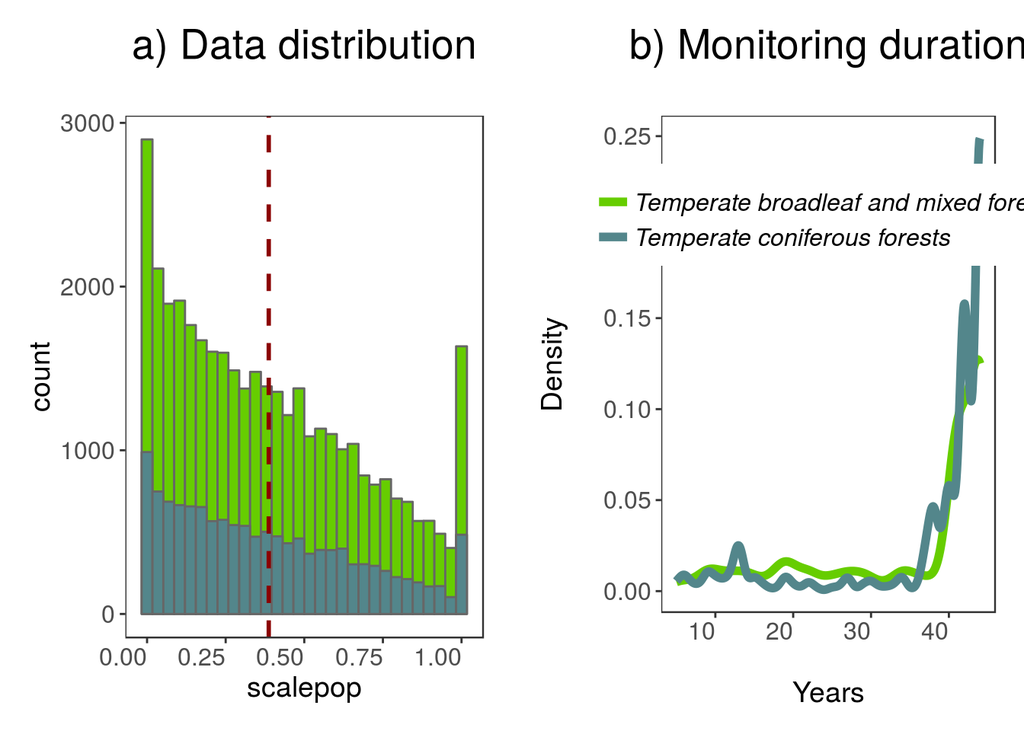

```r
# Arrange in a panel
forest_panel <- grid.arrange(forest_histo, duration_forests, ncol = 2)
```

# Modeling

```r
scalepop_vs_year <- function(df){
  lm(scalepop ~ year, data = df)
}
```

Calculate population change for each forest population 1785 models in one go! Using pipes and purrr and broom

```r
# check names
colnames(LPD_forest)
```

```
##  [1] "id"
##  [2] "data_source_citation"
##  [3] "class"
##  [4] "order"
##  [5] "family"
##  [6] "genus"
##  [7] "species"
##  [8] "sub_species"
##  [9] "authority"
## [10] "common_name"
## [11] "location_of_population"
## [12] "country_list"
## [13] "region"
## [14] "decimal_latitude"
## [15] "decimal_longitude"
```

[output cut: 17 more lines]

```r
# calculate the models
forest_slopes <- LPD_forest %>%
  select(decimal_latitude, decimal_longitude, class, species_name,
           id, duration, location_of_population, scalepop, year) %>%
  group_by(decimal_latitude, decimal_longitude, class, species_name,
           id, duration, location_of_population) %>%
  nest() %>%
  mutate(fit = purrr::map(data, scalepop_vs_year),  ## call lm function
         tidyfit = purrr::map(fit, broom::tidy)) %>%  ## transform results to tidy data
  unnest(tidyfit) %>%
  ungroup() %>%
  filter(term == "year") %>%
  select(-term) %>%
  arrange(id)

dim(forest_slopes)
```

```
## [1] 1785   11
```

```r
#[1] 1785   11
head(forest_slopes)
```

```
## # A tibble: 6 x 11
##   decimal_latitude decimal_longitude class  species_name    id    duration
##   <chr>            <chr>             <chr>  <chr>           <chr>    <dbl>
## 1 44.36667         15.43333          Aves   Gyps fulvus     10361      17.
## 2 44.36667         15.43333          Aves   Gyps fulvus     10362      17.
## 3 -36.65806        175.84            Repti… Oligosoma alani 10383       6.
## 4 -36.65806        175.84            Repti… Oligosoma whit… 10385      11.
## 5 -36.65806        175.84            Repti… Oligosoma sute… 10386       6.
## 6 50.73333         -2.13333          Repti… Coronella aust… 10388      12.
## # ... with 5 more variables: location_of_population <chr>, estimate <dbl>,
## #   std.error <dbl>, statistic <dbl>, p.value <dbl>
```

# Visualising results

Now we can visualise the outputs of all our models and see how they vary based on study duration. We will add density histograms along the margins of the graph which makes for a more informative graph using the ggMarginal() function from the ggExtra package. Note that ggExtra is also an addin in RStudio

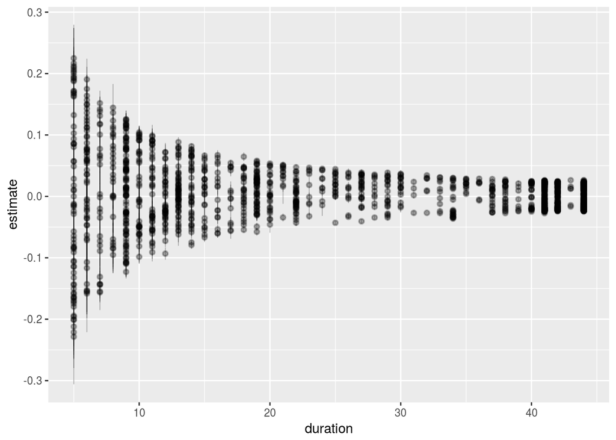

```r
# Plotting slope estimates and standard errors for all populations
# and adding histograms along the margins
(ggplot(forest_slopes, aes(x = duration, y = estimate)) +
   geom_pointrange(aes(ymin = estimate - std.error,
                       ymax = estimate + std.error),
                   alpha = 0.3, size = 0.3) )
```

With the theme

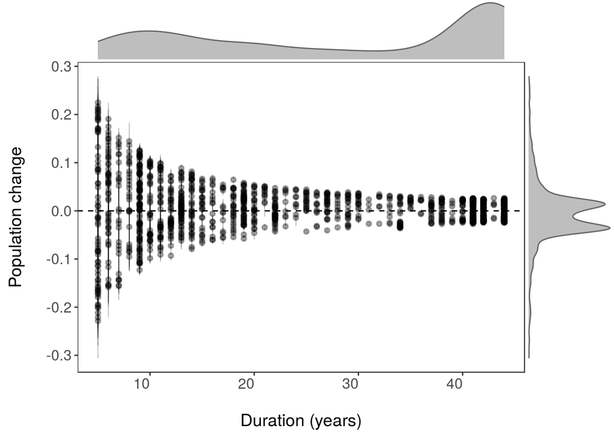

```r
all_slopes <- ggplot(forest_slopes, aes(x = duration, y = estimate)) +
    geom_pointrange(aes(ymin = estimate - std.error,
                        ymax = estimate + std.error),
                    alpha = 0.3, size = 0.3) +
   geom_hline(yintercept = 0, linetype = "dashed") +
   theme_LPD() +
   ylab("Population change\n") +
   xlab("\nDuration (years)")

ggExtra::ggMarginal(
    p = all_slopes,
    type = "density",
    margins = "both",
    size = 5,
    colour = "gray40",
    fill = "gray"
  )
```